# Seguimiento6 - PROMSACE

### Individuos por grupos

Primero crearemos una base de datos de respaldo que ayude a agrupar los individuos debido a que hemos eliminado filas por su poca frecuencia de respuestas en la respectiva categoria.

#### Base de datos de respaldo

```r
bbdd.activa.rem.resp <- bbdd %>%
    filter(`Recursos humanos` != "Sin Respuesta")

bbdd.activa.rem.resp <- bbdd.activa.rem.resp %>%
    filter(`Potenciar conocimientos y habilidades de los servidores civiles` != "Sin Respuesta")

#-------------------

bbdd.activa.rem.resp$`Recursos humanos` <- factor(bbdd.activa.rem.resp$`Recursos humanos`, levels = c("Si", "No"))

#-------------------

bbdd.activa.rem.resp$`Modernización de la Gestión Pública` <- factor(bbdd.activa.rem.resp$`Modernización de la Gestión Pública`, levels = c("Si", "No"))

#-------------------

bbdd.activa.rem.resp$`Potenciar conocimientos y habilidades de los servidores civiles` <- factor(bbdd.activa.rem.resp$`Potenciar conocimientos y habilidades de los servidores civiles`, levels = c("Si", "No"))

#-------------------

bbdd.activa.rem.resp$`Articular labores entre áreas` <- factor(bbdd.activa.rem.resp$`Articular labores entre áreas`, levels = c("Si", "No"))

#-------------------

bbdd.activa.rem.resp$`Mejorar los sistemas informáticos y sistematizar procesos` <- factor(bbdd.activa.rem.resp$`Mejorar los sistemas informáticos y sistematizar procesos`, levels = c("Si", "No"))

head(bbdd.activa.rem.resp)
```

```
## # A tibble: 6 x 35
##   Fecha               lista `Traba administ~ `Recursos human~ Abastecimiento
##   <dttm>              <fct> <chr>            <fct>            <fct>
## 1 2020-02-28 10:16:04 Web ~ x                No               Si
## 2 2020-02-28 11:03:11 Web ~ Prueba           No               No
## 3 2020-02-28 12:01:00 Web ~ prueba GYA       No               Si
## 4 2020-02-28 13:41:09 Web ~ Que tengo que h~ No               No
## 5 2020-02-28 13:41:35 Web ~ Demora ( pago d~ No               No
## 6 2020-02-28 13:41:53 Web ~ Traba: Justific~ Si               No
## # ... with 30 more variables: `Presupuesto público` <fct>, Tesorería <fct>,
## #   Contabilidad <fct>, Control <fct>, `Inversión pública` <fct>, `Planeamiento
## #   estratégico` <fct>, `Modernización de la Gestión Pública` <fct>, `No
## #   sé` <fct>, Otro <fct>, `Cambiar el marco normativo` <fct>, `Potenciar
## #   conocimientos y habilidades de los servidores civiles` <fct>, `Articular
## #   labores entre áreas` <fct>, `Mejorar los sistemas informáticos y
## #   sistematizar procesos` <fct>, `Mejorar la coordinación con el ente rector y
## #   otras instituciones` <fct>, `Entidad publica` <chr>, Identificado <fct>,
## #   Priorizado <fct>, `Nivel de gobierno` <fct>, `Organo de pertenencia` <fct>,
## #   Sexo <fct>, `Años trabajando en el Estado` <fct>, completa <chr>,
## #   año <dbl>, mes <dbl>, dia <int>, hora <int>, minuto <dttm>, segundo <dbl>,
## #   dia_de_la_semana <ord>, semana <dbl>
```

#### Agrupados por lista

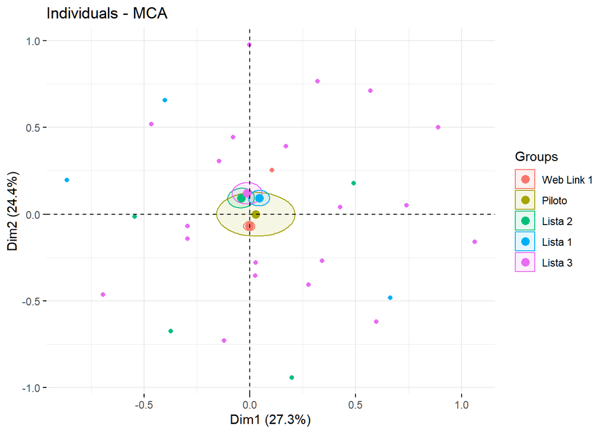

```r
fviz_mca_ind(res.mca, label = "none", habillage = bbdd.activa.rem.resp$lista, addEllipses = TRUE, ellipse.type = "confidence", ggtheme = theme_minimal())
```

#### Agrupados por nivel de gobierno

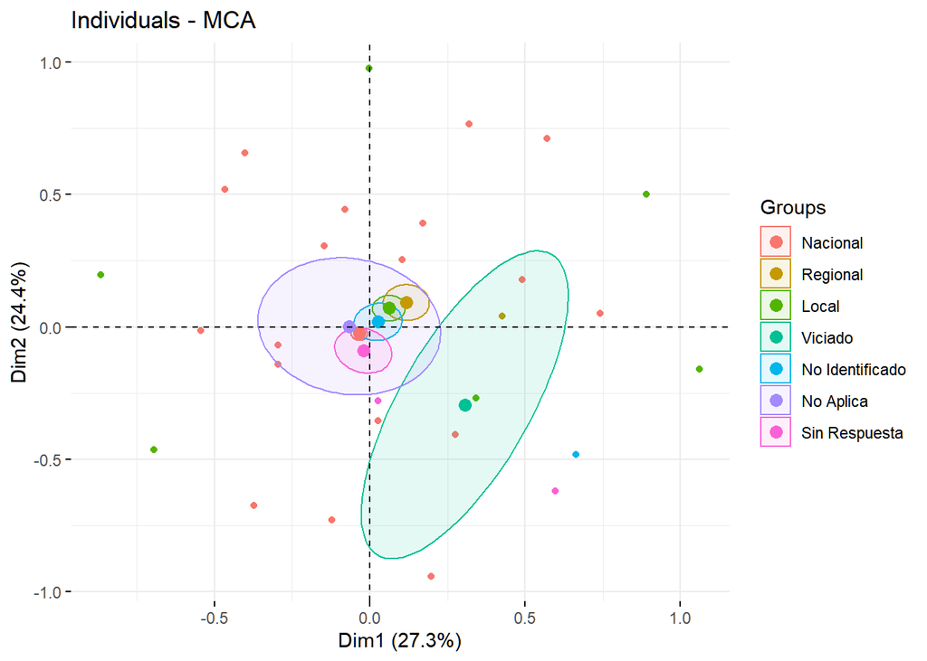

```r
fviz_mca_ind(res.mca, label = "none", habillage = bbdd.activa.rem.resp$`Nivel de gobierno`, addEllipses = TRUE, ellipse.type = "confidence", ggtheme = theme_minimal())
```

#### Agrupados por organo de pertenencia

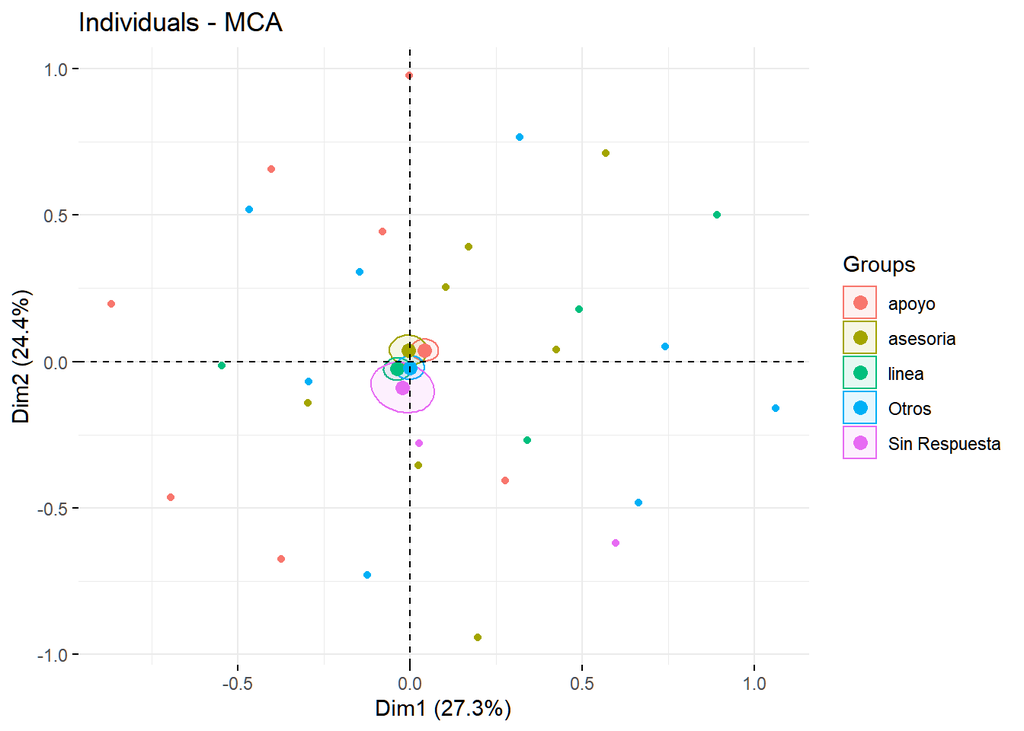

```r
fviz_mca_ind(res.mca, label = "none", habillage = bbdd.activa.rem.resp$`Organo de pertenencia`, addEllipses = TRUE, ellipse.type = "confidence", ggtheme = theme_minimal())
```

#### Agrupados por sexo

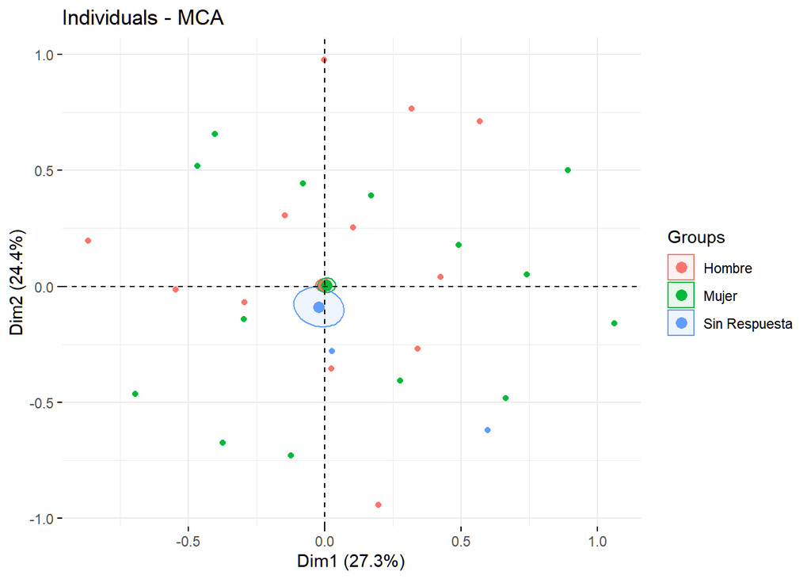

```r
fviz_mca_ind(res.mca, label = "none", habillage = bbdd.activa.rem.resp$Sexo, addEllipses = TRUE, ellipse.type = "confidence", ggtheme = theme_minimal())
```

#### Agrupados por años trabajando en el estado

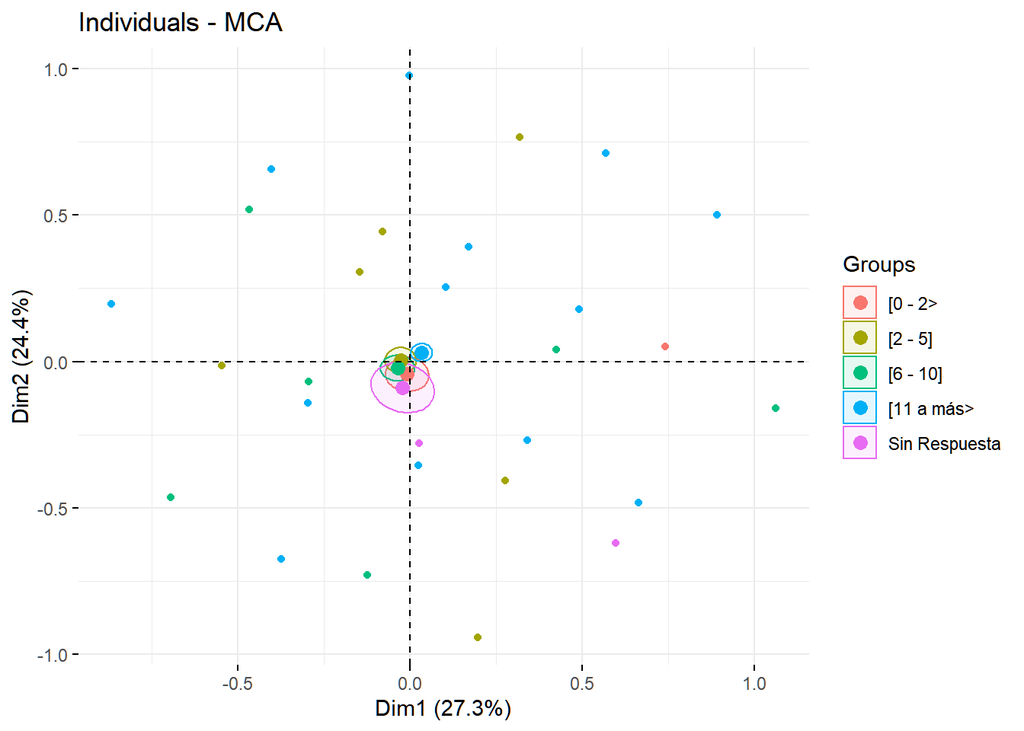

```r
fviz_mca_ind(res.mca, label = "none", habillage = bbdd.activa.rem.resp$`Años trabajando en el Estado`, addEllipses = TRUE, ellipse.type = "confidence", ggtheme = theme_minimal())
```

## Descripcion de las dimensiones

```r
res.desc <- dimdesc(res.mca, axes = c(1, 2))
```

### Descripcion de la dimension 1

```r
res.desc[[1]]
```

```
## $quali
##                                                                         R2
## Potenciar conocimientos y habilidades de los servidores civiles 0.35538336
## Mejorar los sistemas informáticos y sistematizar procesos       0.55561347
## Recursos humanos                                                0.23810323
## Modernización de la Gestión Pública                             0.16941940
## Articular labores entre áreas                                   0.04481597
##                                                                       p.value
## Potenciar conocimientos y habilidades de los servidores civiles  0.000000e+00
## Mejorar los sistemas informáticos y sistematizar procesos        0.000000e+00
## Recursos humanos                                                1.490510e-220
## Modernización de la Gestión Pública                             3.315284e-151
## Articular labores entre áreas                                    9.788863e-39
##
## $category
##                                                                                                                                      Estimate
## Mejorar los sistemas informáticos y sistematizar procesos=Mejorar los sistemas informáticos y sistematizar procesos_No              0.3896196
## Potenciar conocimientos y habilidades de los servidores civiles=Potenciar conocimientos y habilidades de los servidores civiles_Si  0.3168875
## Recursos humanos=Recursos humanos_Si                                                                                                0.2719953
## Modernización de la Gestión Pública=Modernización de la Gestión Pública_No                                                          0.2188645
## Articular labores entre áreas=Articular labores entre áreas_Si                                                                      0.1168447
## Articular labores entre áreas=Articular labores entre áreas_No                                                                     -0.1168447
## Modernización de la Gestión Pública=Modernización de la Gestión Pública_Si                                                         -0.2188645
## Recursos humanos=Recursos humanos_No                                                                                               -0.2719953
## Mejorar los sistemas informáticos y sistematizar procesos=Mejorar los sistemas informáticos y sistematizar procesos_Si             -0.3896196
## Potenciar conocimientos y habilidades de los servidores civiles=Potenciar conocimientos y habilidades de los servidores civiles_No -0.3168875
##                                                                                                                                          p.value
## Mejorar los sistemas informáticos y sistematizar procesos=Mejorar los sistemas informáticos y sistematizar procesos_No              0.000000e+00
## Potenciar conocimientos y habilidades de los servidores civiles=Potenciar conocimientos y habilidades de los servidores civiles_Si  0.000000e+00
## Recursos humanos=Recursos humanos_Si                                                                                               1.490510e-220
## Modernización de la Gestión Pública=Modernización de la Gestión Pública_No                                                         3.315284e-151
## Articular labores entre áreas=Articular labores entre áreas_Si                                                                      9.788863e-39
## Articular labores entre áreas=Articular labores entre áreas_No                                                                      9.788863e-39
## Modernización de la Gestión Pública=Modernización de la Gestión Pública_Si                                                         3.315284e-151
## Recursos humanos=Recursos humanos_No                                                                                               1.490510e-220
## Mejorar los sistemas informáticos y sistematizar procesos=Mejorar los sistemas informáticos y sistematizar procesos_Si              0.000000e+00
## Potenciar conocimientos y habilidades de los servidores civiles=Potenciar conocimientos y habilidades de los servidores civiles_No  0.000000e+00
##
## attr(,"class")
## [1] "condes" "list "
```

### Descripcion de la dimension 2

```r
res.desc[[2]]
```

```
## $quali
##                                                                         R2
## Articular labores entre áreas                                   0.59638506
## Potenciar conocimientos y habilidades de los servidores civiles 0.31042596
## Recursos humanos                                                0.13799779
## Mejorar los sistemas informáticos y sistematizar procesos       0.10721518
## Modernización de la Gestión Pública                             0.06614067
##                                                                       p.value
## Articular labores entre áreas                                    0.000000e+00
## Potenciar conocimientos y habilidades de los servidores civiles 1.173038e-300
## Recursos humanos                                                2.327357e-121
## Mejorar los sistemas informáticos y sistematizar procesos        3.819675e-93
## Modernización de la Gestión Pública                              6.113822e-57
##
## $category
##                                                                                                                                      Estimate
## Articular labores entre áreas=Articular labores entre áreas_No                                                                      0.4029096
## Potenciar conocimientos y habilidades de los servidores civiles=Potenciar conocimientos y habilidades de los servidores civiles_Si  0.2799543
## Recursos humanos=Recursos humanos_Si                                                                                                0.1957341
## Mejorar los sistemas informáticos y sistematizar procesos=Mejorar los sistemas informáticos y sistematizar procesos_Si              0.1617835
## Modernización de la Gestión Pública=Modernización de la Gestión Pública_Si                                                          0.1292646
## Modernización de la Gestión Pública=Modernización de la Gestión Pública_No                                                         -0.1292646
## Mejorar los sistemas informáticos y sistematizar procesos=Mejorar los sistemas informáticos y sistematizar procesos_No             -0.1617835
## Recursos humanos=Recursos humanos_No                                                                                               -0.1957341
## Potenciar conocimientos y habilidades de los servidores civiles=Potenciar conocimientos y habilidades de los servidores civiles_No -0.2799543
## Articular labores entre áreas=Articular labores entre áreas_Si                                                                     -0.4029096
##                                                                                                                                          p.value
## Articular labores entre áreas=Articular labores entre áreas_No                                                                      0.000000e+00
## Potenciar conocimientos y habilidades de los servidores civiles=Potenciar conocimientos y habilidades de los servidores civiles_Si 1.173038e-300
## Recursos humanos=Recursos humanos_Si                                                                                               2.327357e-121
## Mejorar los sistemas informáticos y sistematizar procesos=Mejorar los sistemas informáticos y sistematizar procesos_Si              3.819675e-93
## Modernización de la Gestión Pública=Modernización de la Gestión Pública_Si                                                          6.113822e-57
## Modernización de la Gestión Pública=Modernización de la Gestión Pública_No                                                          6.113822e-57
## Mejorar los sistemas informáticos y sistematizar procesos=Mejorar los sistemas informáticos y sistematizar procesos_No              3.819675e-93
## Recursos humanos=Recursos humanos_No                                                                                               2.327357e-121
## Potenciar conocimientos y habilidades de los servidores civiles=Potenciar conocimientos y habilidades de los servidores civiles_No 1.173038e-300
## Articular labores entre áreas=Articular labores entre áreas_Si                                                                      0.000000e+00
##
## attr(,"class")
## [1] "condes" "list "
```

## Elementos complementarios

Creamos otra base de datos que nos ayude a seleccionar solo las variables complementarias.

```r
bbdd.activa.rem.resp2 <- bbdd.activa.rem.resp %>%
    select(`Recursos humanos`, `Modernización de la Gestión Pública`, `Potenciar conocimientos y habilidades de los servidores civiles`, `Articular labores entre áreas`, `Mejorar los sistemas informáticos y sistematizar procesos`, lista, `Nivel de gobierno`, `Organo de pertenencia`, Sexo, `Años trabajando en el Estado`)

head(bbdd.activa.rem.resp2)
```

```
## # A tibble: 6 x 10
##   `Recursos human~ `Modernización ~ `Potenciar cono~ `Articular labo~
##   <fct>            <fct>            <fct>            <fct>
## 1 No               No               Si               No
## 2 No               No               No               No
## 3 No               No               Si               No
## 4 No               Si               No               Si
## 5 No               No               No               No
## 6 Si               No               No               Si
## # ... with 6 more variables: `Mejorar los sistemas informáticos y sistematizar
## #   procesos` <fct>, lista <fct>, `Nivel de gobierno` <fct>, `Organo de
## #   pertenencia` <fct>, Sexo <fct>, `Años trabajando en el Estado` <fct>
```

```r
res2.mca <- MCA(bbdd.activa.rem.resp2, ind.sup = 1:10, quali.sup = 6:10, graph = FALSE)
```

Categorias de variables cualitativas complementarias.

```r
res2.mca$quali.sup
```

```
## $coord
##                                                   Dim 1        Dim 2
## Web Link 1                                 -0.007447894 -0.140024947
## Piloto                                      0.052540691 -0.002550438
## Lista 2                                    -0.079048372  0.187311820
## Lista 1                                     0.083770350  0.186273011
## Lista 3                                    -0.024332697  0.243177515
## Nivel de gobierno_Nacional                 -0.064415962 -0.050344351
## Nivel de gobierno_Regional                  0.225798443  0.184773008
## Nivel de gobierno_Local                     0.118190314  0.142711283
## Nivel de gobierno_Viciado                   0.626417754 -0.845229325
## Nivel de gobierno_No Identificado           0.056577887  0.033069863
## Nivel de gobierno_No Aplica                -0.126432184  0.004191575
## Nivel de gobierno_Sin Respuesta            -0.048297321 -0.190066662
## Organo de pertenencia_apoyo                 0.081477486  0.079214506
## Organo de pertenencia_asesoria             -0.009376169  0.082921798
## Organo de pertenencia_linea                -0.070281798 -0.052702309
## Organo de pertenencia_Otros                 0.001609713 -0.042763085
## Organo de pertenencia_Sin Respuesta        -0.048297321 -0.190066662
## Sexo_Hombre                                -0.006862930  0.011244579
## Sexo_Mujer                                  0.014023218  0.007241667
## Sexo_Sin Respuesta                         -0.048297321 -0.190066662
## Años trabajando en el Estado_[0 - 2>       -0.013876179 -0.089569104
## Años trabajando en el Estado_[2 - 5]       -0.051041686  0.008713094
## Años trabajando en el Estado_[6 - 10]      -0.069481399 -0.045021462
## Años trabajando en el Estado_[11 a más>     0.064684789  0.061527435
## Años trabajando en el Estado_Sin Respuesta -0.048297321 -0.190066662
##                                                    Dim 3        Dim 4
## Web Link 1                                 -0.0351158711 -0.067247761
## Piloto                                     -0.2940968196 -0.465930995
## Lista 2                                     0.0949139859  0.186617327
## Lista 1                                     0.0211008272  0.036005270
## Lista 3                                     0.0892451823  0.160542044
## Nivel de gobierno_Nacional                 -0.0160395048  0.006310606
## Nivel de gobierno_Regional                  0.0527015353 -0.048305062
## Nivel de gobierno_Local                     0.0786750380  0.046829870
## Nivel de gobierno_Viciado                  -0.4190353133 -0.418193747
## Nivel de gobierno_No Identificado           0.0343330276  0.005030166
## Nivel de gobierno_No Aplica                -0.1663429116 -0.200879923
## Nivel de gobierno_Sin Respuesta            -0.1801192911 -0.136070673
```

[output cut: 172 more lines]

```
## Años trabajando en el Estado_Sin Respuesta -1.84408549 -3.1523649
##
## $eta2
##                                     Dim 1       Dim 2       Dim 3       Dim 4
## lista                        0.0021846684 0.027955904 0.003802217 0.012451910
## Nivel de gobierno            0.0099762844 0.010330458 0.003376964 0.001867769
## Organo de pertenencia        0.0034513446 0.005711575 0.004238893 0.004074637
## Sexo                         0.0002187695 0.001803350 0.001816718 0.001386297
## Años trabajando en el Estado 0.0034246002 0.004715951 0.004096365 0.001443387
##                                     Dim 5
## lista                        0.0006848007
## Nivel de gobierno            0.0040147181
## Organo de pertenencia        0.0032187201
## Sexo                         0.0061379953
## Años trabajando en el Estado 0.0058832228
```

Individuos complementarios: usaremos los 10 primeros individuos ya estudiados en el analisis.

```r
res2.mca$ind.sup
```

```
## $coord
##         Dim 1      Dim 2       Dim 3      Dim 4        Dim 5
## 1   0.4915745  0.1758542 -0.05245783 -0.7292501  0.061244030
## 2   0.0254393 -0.2810877 -0.34955588 -0.5005484 -0.450975915
## 3   0.4915745  0.1758542 -0.05245783 -0.7292501  0.061244030
## 4  -0.1237096 -0.7309707  0.69249673  0.1084333 -0.246420623
## 5   0.0254393 -0.2810877 -0.34955588 -0.5005484 -0.450975915
## 6   0.5959690 -0.6204389 -0.27066060  0.6382611 -0.204738192
## 7   0.1719476  0.3878954  0.70634211 -0.5068072 -0.177844795
## 8  -0.8649769  0.1986540  0.18310499 -0.0114875 -0.159232318
## 9   0.1719476  0.3878954  0.70634211 -0.5068072 -0.177844795
## 10  0.1959173 -0.9430119 -0.06630320 -0.1140096 -0.007331797
##
## $cos2
##           Dim 1      Dim 2       Dim 3        Dim 4        Dim 5
## 1  0.2980045580 0.03813728 0.003393632 0.6558388937 4.625639e-03
## 2  0.0009868604 0.12048386 0.186328195 0.3820651697 3.101359e-01
## 3  0.2980045580 0.03813728 0.003393632 0.6558388937 4.625639e-03
## 4  0.0138918956 0.48501409 0.435301258 0.0106728375 5.511992e-02
## 5  0.0009868604 0.12048386 0.186328195 0.3820651697 3.101359e-01
## 6  0.2812908098 0.30486410 0.058017400 0.3226301457 3.319754e-02
## 7  0.0305613534 0.15552837 0.515715876 0.2655008138 3.269359e-02
## 8  0.8836871955 0.04661052 0.039599516 0.0001558622 2.994691e-02
## 9  0.0305613534 0.15552837 0.515715876 0.2655008138 3.269359e-02
## 10 0.0406131129 0.94092535 0.004651466 0.0137531914 5.687767e-05
```

### Graficos

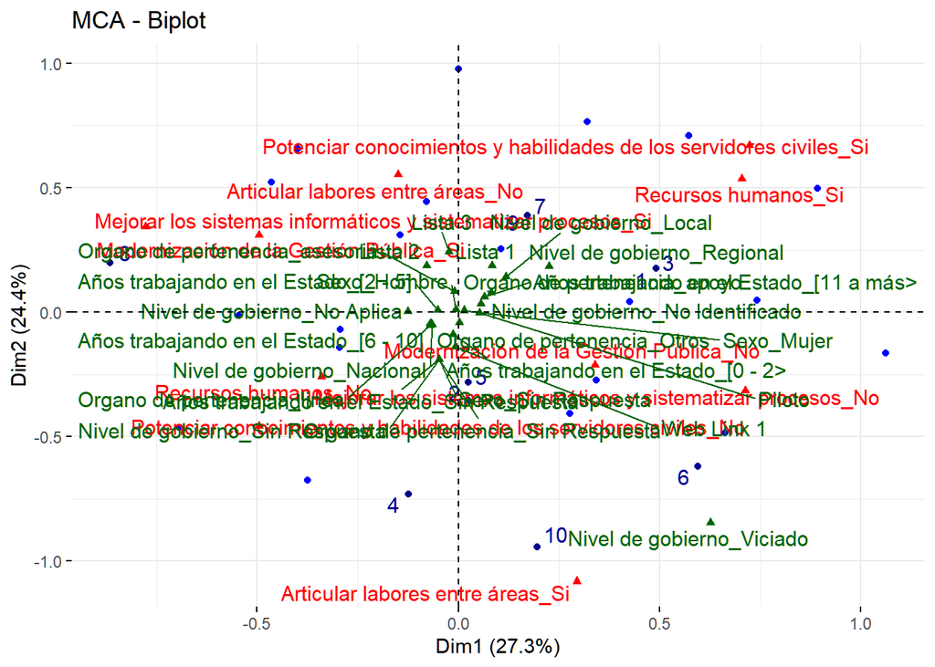

```r
fviz_mca_biplot(res2.mca, label = "var", repel = TRUE, ggtheme = theme_minimal())
```

#### Correlacion entre variables activas y complementarias

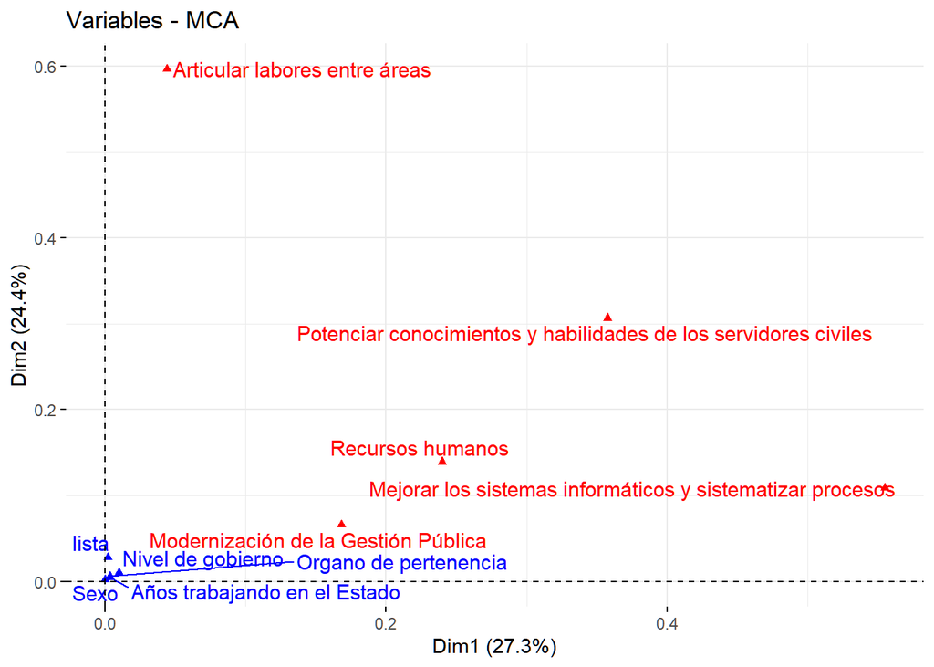

```r
fviz_mca_var(res2.mca, choice = "mca.cor", repel = TRUE)
```

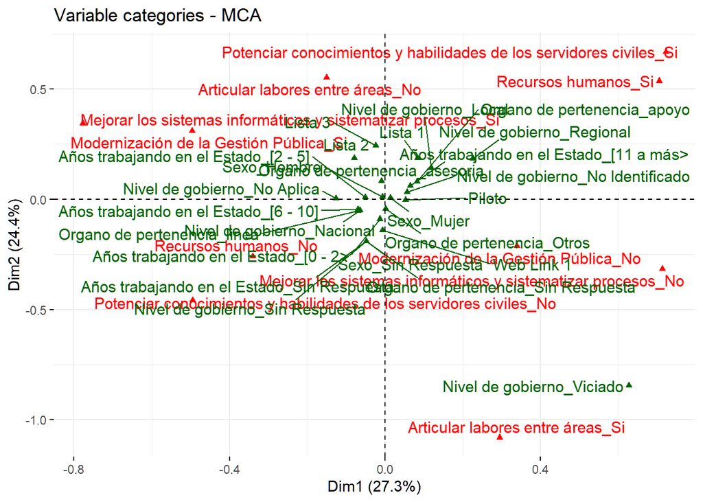

```r
fviz_mca_var(res2.mca, repel = TRUE, ggtheme = theme_minimal())
```

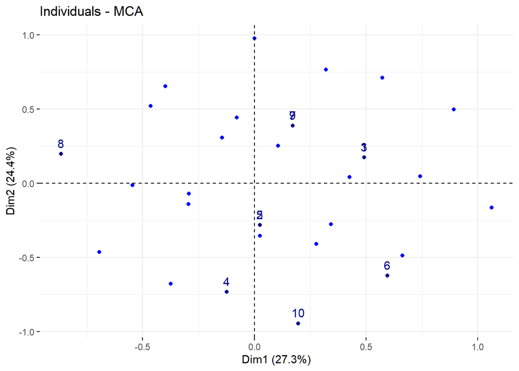

```r
fviz_mca_ind(res2.mca, label = "ind.sup", ggtheme = theme_minimal())
```

## Filtrando principales resultados

Filtraremos los resultados mas importantes.

Visualizar categorias con el cos2 >= 0.4

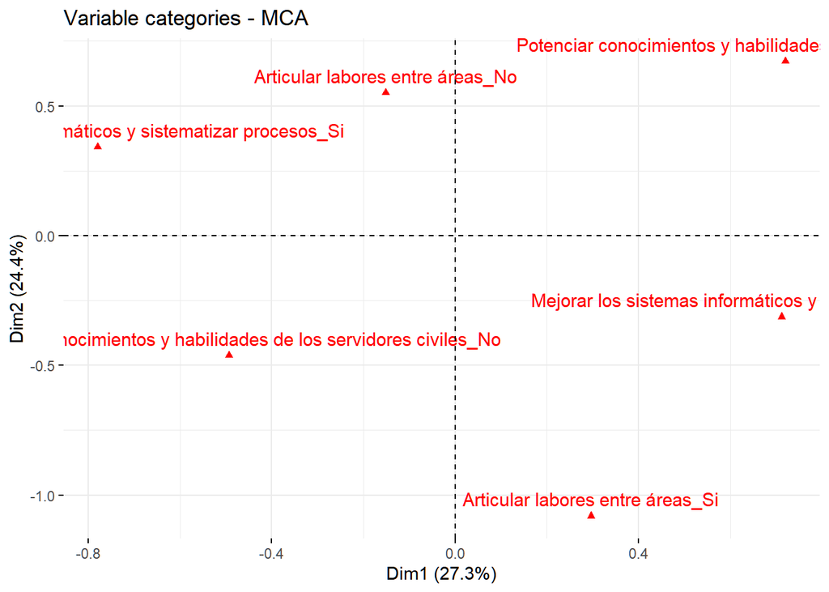

```r
fviz_mca_var(res.mca, select.var = list(cos2 = 0.4))
```

Top 3 categorias con el cos2 mas alto

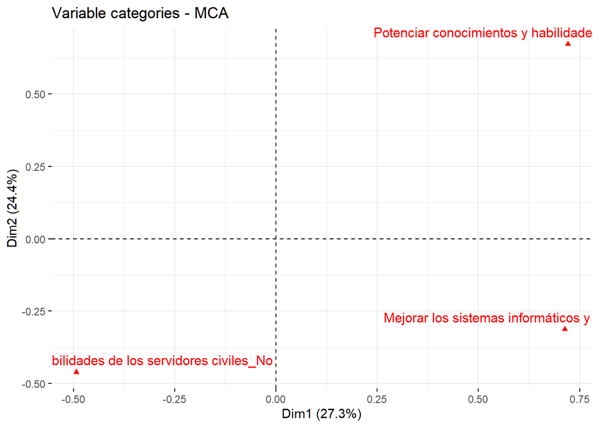

```r
fviz_mca_var(res.mca, select.var = list(cos2 = 3))
```

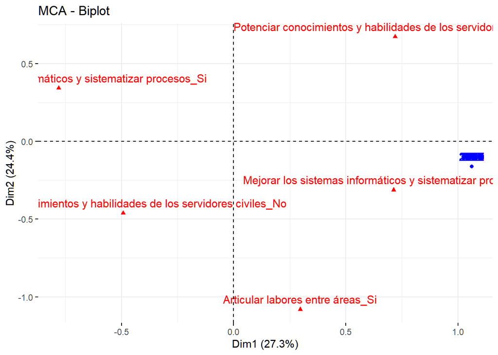

```r
fviz_mca_biplot(res.mca, select.ind = list(contrib = 94), select.var = list(contrib = 5), ggtheme = theme_minimal())
```

Concluimos que puede haber una asociacion entre los 94 individuos agrupados y la categoria “no” de la variable “Mejorar los sistemas informaticos y sistematizar procesos”.

## Agrupacion jerarquica

Formaremos grupos de individuos semejantes con las variables procedentes de la pregunta 2 y 3 cuyas frecuencias de categorias no las hayan excluido del analisis y consideramos a las variables complementarias a predecir las cuales son “lista”, “nivel de gobierno”, “organo de pertenencia”, “sexo” y "años trabajando para el estado.

```r
res3.mca <- MCA(bbdd.activa.rem.resp2, ncp = 4, quali.sup = 6:10, graph = FALSE)
```

Aplicamos agrupamientos jerarquicos sobre los resultados del analisis de correspondencia multiple.

```r
res.hcpc <- HCPC(res3.mca, graph = FALSE)
```

Dendograma

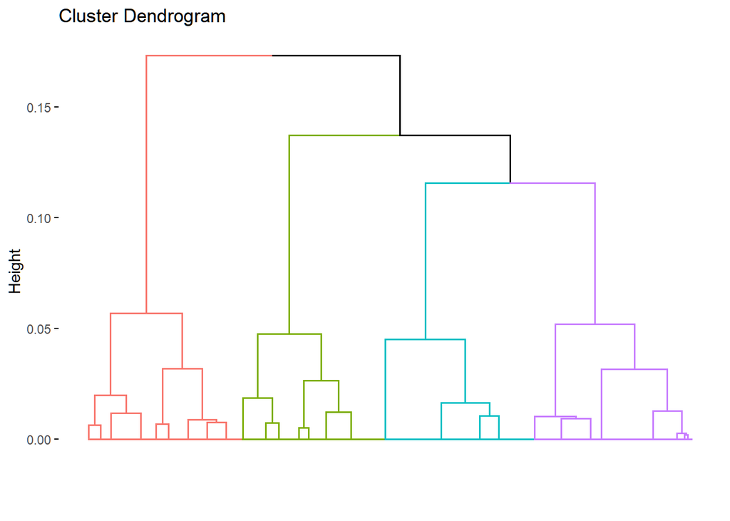

```r
fviz_dend(res.hcpc, show_labels = FALSE)
```

Mapa factor de individuos

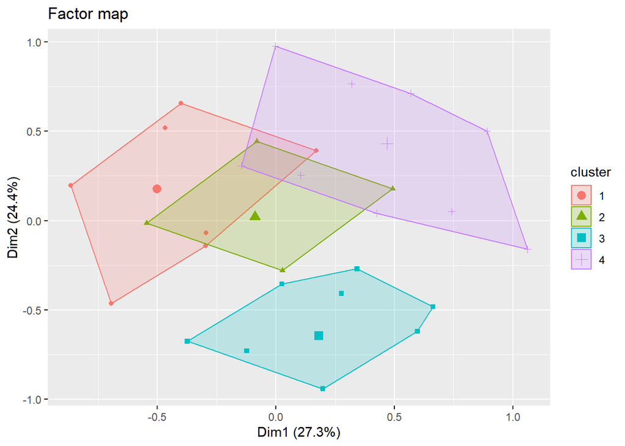

```r
fviz_cluster(res.hcpc, geom = "point", main = "Factor map")
```

### Descripcion por variables

```r
res.hcpc$desc.var$test.chi2
```

```
##                                                                       p.value
## Recursos.humanos                                                 0.000000e+00
## Modernización.de.la.Gestión.Pública                              0.000000e+00
## Articular.labores.entre.áreas                                    0.000000e+00
## Potenciar.conocimientos.y.habilidades.de.los.servidores.civiles 2.931927e-116
## Mejorar.los.sistemas.informáticos.y.sistematizar.procesos       4.677307e-116
## lista                                                            2.515621e-19
## Organo.de.pertenencia                                            9.648122e-05
## Años.trabajando.en.el.Estado                                     1.049874e-03
## Nivel.de.gobierno                                                1.131392e-03
## Sexo                                                             2.038425e-03
##                                                                 df
## Recursos.humanos                                                 3
## Modernización.de.la.Gestión.Pública                              3
## Articular.labores.entre.áreas                                    3
## Potenciar.conocimientos.y.habilidades.de.los.servidores.civiles  3
## Mejorar.los.sistemas.informáticos.y.sistematizar.procesos        3
## lista                                                           12
## Organo.de.pertenencia                                           12
## Años.trabajando.en.el.Estado                                    12
## Nivel.de.gobierno                                               18
## Sexo                                                             6
```

### Descripcion por categorias

```r
res.hcpc$desc.var$category
```

```
## $`1`
##                                                                                                                                     Cla/Mod
## Modernización.de.la.Gestión.Pública=Modernización de la Gestión Pública_Si                                                         66.20000
## Mejorar.los.sistemas.informáticos.y.sistematizar.procesos=Mejorar los sistemas informáticos y sistematizar procesos_Si             42.18573
## Recursos.humanos=Recursos humanos_No                                                                                               34.93590
## Articular.labores.entre.áreas=Articular labores entre áreas_No                                                                     32.63889
## Potenciar.conocimientos.y.habilidades.de.los.servidores.civiles=Potenciar conocimientos y habilidades de los servidores civiles_No 31.70843
## lista=Lista 2                                                                                                                      33.78378
## lista=Lista 3                                                                                                                      33.51499
## Años.trabajando.en.el.Estado=Años trabajando en el Estado_[6 - 10]                                                                 30.29046
## Organo.de.pertenencia=Organo de pertenencia_Otros                                                                                  24.29058
## Años.trabajando.en.el.Estado=Años trabajando en el Estado_[0 - 2>                                                                  21.99546
## lista=Web Link 1                                                                                                                   24.38458
## Potenciar.conocimientos.y.habilidades.de.los.servidores.civiles=Potenciar conocimientos y habilidades de los servidores civiles_Si 19.76048
## Articular.labores.entre.áreas=Articular labores entre áreas_Si                                                                     15.52000
## Recursos.humanos=Recursos humanos_Si                                                                                               10.06656
## Mejorar.los.sistemas.informáticos.y.sistematizar.procesos=Mejorar los sistemas informáticos y sistematizar procesos_No             12.83644
## Modernización.de.la.Gestión.Pública=Modernización de la Gestión Pública_No                                                          0.00000
##                                                                                                                                       Mod/Cla
## Modernización.de.la.Gestión.Pública=Modernización de la Gestión Pública_Si                                                         100.000000
## Mejorar.los.sistemas.informáticos.y.sistematizar.procesos=Mejorar los sistemas informáticos y sistematizar procesos_Si              75.025176
## Recursos.humanos=Recursos humanos_No                                                                                                87.814703
## Articular.labores.entre.áreas=Articular labores entre áreas_No                                                                      80.463243
## Potenciar.conocimientos.y.habilidades.de.los.servidores.civiles=Potenciar conocimientos y habilidades de los servidores civiles_No  70.090634
## lista=Lista 2                                                                                                                       15.105740
## lista=Lista 3                                                                                                                       12.386707
## Años.trabajando.en.el.Estado=Años trabajando en el Estado_[6 - 10]                                                                  22.054381
## Organo.de.pertenencia=Organo de pertenencia_Otros                                                                                   21.550856
## Años.trabajando.en.el.Estado=Años trabajando en el Estado_[0 - 2>                                                                    9.768379
## lista=Web Link 1                                                                                                                    52.870091
## Potenciar.conocimientos.y.habilidades.de.los.servidores.civiles=Potenciar conocimientos y habilidades de los servidores civiles_Si  29.909366
## Articular.labores.entre.áreas=Articular labores entre áreas_Si                                                                      19.536757
## Recursos.humanos=Recursos humanos_Si                                                                                                12.185297
## Mejorar.los.sistemas.informáticos.y.sistematizar.procesos=Mejorar los sistemas informáticos y sistematizar procesos_No              24.974824
## Modernización.de.la.Gestión.Pública=Modernización de la Gestión Pública_No                                                           0.000000
##                                                                                                                                       Global
## Modernización.de.la.Gestión.Pública=Modernización de la Gestión Pública_Si                                                         40.562466
## Mejorar.los.sistemas.informáticos.y.sistematizar.procesos=Mejorar los sistemas informáticos y sistematizar procesos_Si             47.755544
## Recursos.humanos=Recursos humanos_No                                                                                               67.495944
## Articular.labores.entre.áreas=Articular labores entre áreas_No                                                                     66.197945
```

[output cut: 347 more lines]

```
## Años.trabajando.en.el.Estado=Años trabajando en el Estado_[11 a más>                                                                 3.515401
## Nivel.de.gobierno=Nivel de gobierno_Local                                                                                            3.456898
## lista=Lista 3                                                                                                                        2.853170
## Nivel.de.gobierno=Nivel de gobierno_Regional                                                                                         2.507983
## Años.trabajando.en.el.Estado=Años trabajando en el Estado_Sin Respuesta                                                             -2.918169
## Sexo=Sexo_Sin Respuesta                                                                                                             -2.918169
## Organo.de.pertenencia=Organo de pertenencia_Sin Respuesta                                                                           -2.918169
## Nivel.de.gobierno=Nivel de gobierno_Sin Respuesta                                                                                   -2.918169
## Nivel.de.gobierno=Nivel de gobierno_Nacional                                                                                        -3.612182
## Mejorar.los.sistemas.informáticos.y.sistematizar.procesos=Mejorar los sistemas informáticos y sistematizar procesos_Si              -5.483353
## lista=Web Link 1                                                                                                                    -6.529023
## Modernización.de.la.Gestión.Pública=Modernización de la Gestión Pública_Si                                                          -6.729558
## Articular.labores.entre.áreas=Articular labores entre áreas_Si                                                                     -12.160454
## Potenciar.conocimientos.y.habilidades.de.los.servidores.civiles=Potenciar conocimientos y habilidades de los servidores civiles_No -22.572743
## Recursos.humanos=Recursos humanos_No                                                                                                     -Inf
```

Las variables que caracterizan mas a los clusteres son las variables “Recursos humanos”, “Modernizacion de la Gestion Publica” y “Articular labores entre areas”.

Cada cluster esta caracterizado por una categoria de las variables “Recursos humanos”, “Modernizacion de la Gestion Publica” y “Articular labores entre areas”.

Los individuos que pertenecen al primer cluster marcaron: - “si” a “Modernizacion de la Gestion Publica” - “si” a “Mejorar los sistemas informaticos sistematizar procesos” - “no” a “Recursos humanos” - “no” a “Articular labores entre areas” - “no” a “Potenciar conocimientos y habilidades de los servidores civiles”

Los individuos que pertenecen al segundo cluster marcaron: - “no” a “Modernizacion de la Gestion Publica” - “no” a “Articular labores entre areas” - “no” a “Recursos humanos”.

Los individuos que pertenecen al tercer cluster marcaron: - “si” a “Articular labores entre areas” - “no” a “Mejorar los sistemas informaticos sistematizar procesos” - “no” a “Potenciar conocimientos y habilidades de los servidores civiles” - “no” a “Modernizacion de la Gestion Publica”

Los individuos que pertenecen al cuarto cluster marcaron: - “si” a “Recursos humanos”. - “si” a “Potenciar conocimientos y habilidades de los servidores civiles” - “no” a “Articular labores entre areas” - “no” a “Modernizacion de la Gestion Publica”

## Descripcion por individuos

```r
res.hcpc$desc.ind$para
```

```
## Cluster: 1
##        51        65        69        73        90
## 0.4060512 0.4060512 0.4060512 0.4060512 0.4060512
## ------------------------------------------------------------
## Cluster: 2
##       26       30       40       49       85
## 0.326682 0.326682 0.326682 0.326682 0.326682
## ------------------------------------------------------------
## Cluster: 3
##        10        13        45        47        50
## 0.4097569 0.4097569 0.4097569 0.4097569 0.4097569
## ------------------------------------------------------------
## Cluster: 4
##        14        42        48        56        62
## 0.5030102 0.5030102 0.5030102 0.5030102 0.5030102
```

Los individuos mencionados son los mas tipicos en cada cluster.

## Resumen de concluciones

Puede haber una asociacion entre los 94 individuos agrupados y la categoria “no” de la variable “Mejorar los sistemas informaticos y sistematizar procesos”.

Los individuos que pertenecen al primer grupo marcaron: “si” a “Modernizacion de la Gestion Publica”, “si” a “Mejorar los sistemas informaticos sistematizar procesos”, “no” a “Recursos humanos”, “no” a “Articular labores entre areas” y “no” a “Potenciar conocimientos y habilidades de los servidores civiles”

Los individuos que pertenecen al segundo grupo marcaron: “no” a “Modernizacion de la Gestion Publica”, “no” a “Articular labores entre areas”, “no” a “Recursos humanos”.

Los individuos que pertenecen al tercer grupo marcaron: “si” a “Articular labores entre areas”, “no” a “Mejorar los sistemas informaticos sistematizar procesos”, “no” a “Potenciar conocimientos y habilidades de los servidores civiles” y “no” a “Modernizacion de la Gestion Publica”

Los individuos que pertenecen al cuarto cluster marcaron: “si” a “Recursos humanos”, “si” a “Potenciar conocimientos y habilidades de los servidores civiles”, “no” a “Articular labores entre areas” y “no” a “Modernizacion de la Gestion Publica”

Los individuos mas tipicos en el Cluster 1 son: 51, 65, 69, 73 y 90.

Los individuos mas tipicos en el Cluster 2 son: 26, 30, 40, 49 y 85

Los individuos mas tipicos en el Cluster 3 son: 10, 13, 45, 47 y 50

Los individuos mas tipicos en el Cluster 4 son: 14, 42, 48, 56 y 62

## Otras consideraciones

Se pueden mejorar los clusters en funcion de una distancia adecuada a las variables categoricas que seria la distancia de Hamming pues la distancia que se tomo fue la euclidea.

## Fuente

Clustering Categorical Data Based on Distance Vectors Author(s): Peng Zhang, Xiaogang Wang and Peter X.-K. Song Source: Journal of the American Statistical Association, Vol. 101, No. 473 (Mar., 2006), pp. 355-367